# G9_p2

Hongjin Ren

2022/3/10

```r
library(tidyverse)
library(moderndive)
library(skimr)
library(kableExtra)
library(gridExtra)
library(broom)
library(olsrr)
```

```r
library(gapminder)
library(sjPlot)
library(stats)
library(jtools)
library(MASS)
library(janitor)
library(ROCR)
library(ggplot2)
library(GGally)
coffee <- read_csv("https://raw.githubusercontent.com/brent-strong/DAS2022-Group-09/main/dataset9.csv")
```

- country_of_origin – Country where the coffee bean originates from.
- aroma – Aroma grade (ranging from 0-10)
- flavor – Flavor grade (ranging from 0-10)
- acidity – Acidity grade (ranging from 0-10)
- category_two_defects – Count of category 2 type defects in the batch of coffee beans tested.
- altitiude_mean_meters – Mean altitude of the growers farm (in metres)
- harvested – Year the batch was harvested
- Qualityclass – Quality score for the batch (Good - ≥ 82.5, Poor - <82.5). Note: 82.5 was selected as the cut off as this is the median score for all the batches tested.

```r
coffee %>%
  group_by(country_of_origin) %>%
  summarise(n=n(),Mean=round(mean(altitude_mean_meters,na.rm=T),digits=2), St.Dev=round(sd(altitude_mean_meters,na.rm=T),digits=2),
            Min=min(altitude_mean_meters,na.rm=T), Q1 = quantile(altitude_mean_meters,0.25,na.rm=T), Median=median(altitude_mean_meters,na.rm=T),
            Q3 = quantile(altitude_mean_meters,0.75,na.rm=T), Max=max(altitude_mean_meters,na.rm=T))
```

| country_of_origin | n | Mean | St.Dev | Min | Q1 | Median | Q3 | Max |
| --- | --- | --- | --- | --- | --- | --- | --- | --- |
| Brazil | 116 | 1028.80 | 1110.81 | 1.0000 | 890.000 | 1000.00 | 1200.00 | 11000.00 |
| Burundi | 2 | 1790.00 | 127.28 | 1700.0000 | 1745.000 | 1790.00 | 1835.00 | 1880.00 |
| China | 14 | 1472.14 | 239.46 | 1100.0000 | 1250.000 | 1540.00 | 1637.50 | 1850.00 |
| Colombia | 158 | 1608.20 | 478.80 | 175.0000 | 1550.000 | 1750.00 | 1775.00 | 3850.00 |
| Costa Rica | 41 | 1334.76 | 460.13 | 13.0000 | 1200.000 | 1300.00 | 1700.00 | 1900.00 |
| Cote d?Ivoire | 1 | 200.00 | NA | 200.0000 | 200.000 | 200.00 | 200.00 | 200.00 |
| Ecuador | 3 | 420.00 | 537.40 | 40.0000 | 230.000 | 420.00 | 610.00 | 800.00 |
| El Salvador | 20 | 1337.78 | 110.54 | 1200.0000 | 1250.000 | 1350.00 | 1437.50 | 1500.00 |
| Ethiopia | 38 | 1783.44 | 149.57 | 1493.5200 | 1666.125 | 1787.50 | 1900.00 | 2075.00 |
| Guatemala | 152 | 4322.63 | 23231.79 | 157.8864 | 1310.640 | 1371.60 | 1537.00 | 190164.00 |

[output cut: 24 more lines]

```r
co_Na <- na.omit(coffee)
```

```r
cor(co_Na[2:6])
```

```
##                            aroma      flavor       acidity category_two_defects
## aroma                 1.00000000  0.82937156  0.7491356503          -0.14594972
## flavor                0.82937156  1.00000000  0.8396367164          -0.19038223
## acidity               0.74913565  0.83963672  1.0000000000          -0.13672750
## category_two_defects -0.14594972 -0.19038223 -0.1367274972           1.00000000
## altitude_mean_meters -0.01735196 -0.01247196  0.0007979318          -0.01963494
##                      altitude_mean_meters
## aroma                       -0.0173519613
## flavor                      -0.0124719569
## acidity                      0.0007979318
## category_two_defects        -0.0196349385
## altitude_mean_meters         1.0000000000
```

#factor the respond data

```r
co_Na$class[co_Na$Qualityclass == "Poor"] <- 0
co_Na$class[co_Na$Qualityclass == "Good"] <- 1
co_Na$class <- factor(co_Na$class,
                      levels = c(0,1),
                      labels = c("Poor","Good"))
```

```r
co_Na$level[co_Na$altitude_mean_meters<900]
```

```r
co_Na$level[co_Na$altitude_mean_meters>900 & co_Na$altitude_mean_meters<1200]
```

```r
co_Na$level[co_Na$altitude_mean_meters<900]
```

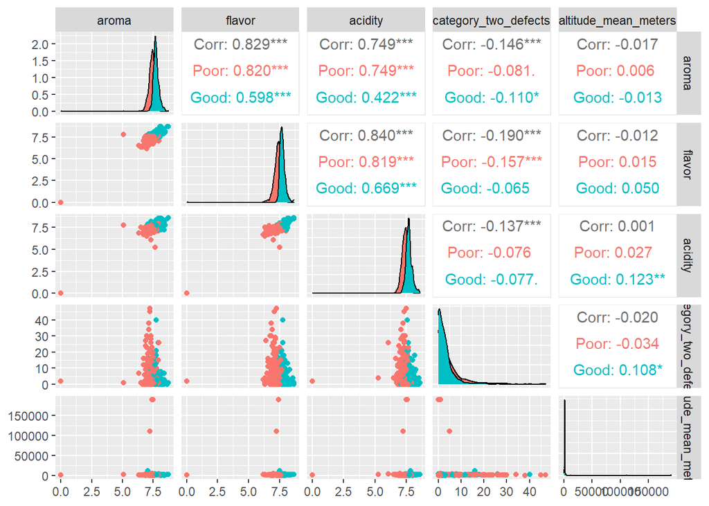

```r
ggpairs(co_Na, columns=2:6,aes(color=class))
```

```r
cor(coffee[2:6])
```

```
##                           aroma     flavor    acidity category_two_defects
## aroma                 1.0000000  0.8163686  0.7305343           -0.1544159
## flavor                0.8163686  1.0000000  0.8173142           -0.1961509
## acidity               0.7305343  0.8173142  1.0000000           -0.1371781
## category_two_defects -0.1544159 -0.1961509 -0.1371781            1.0000000
## altitude_mean_meters         NA         NA         NA                   NA
##                      altitude_mean_meters
## aroma                                  NA
## flavor                                 NA
## acidity                                NA
## category_two_defects                   NA
## altitude_mean_meters                    1
```

```r
coffee %>%
  tabyl(Qualityclass, country_of_origin) %>%
  adorn_percentages() %>%
  adorn_pct_formatting() %>%
  adorn_ns()
```

|  | Qualityclass | Brazil | Burundi | China | Colombia | Costa Rica | Cote d?Ivoire | Ecuador | El Salvador | Ethiopia | Guatemala | Haiti | Honduras | India | Indonesia | Japan | Kenya | Laos | Malawi | Mauritius | Mexico | Myanmar | Nicaragua | Panama | Peru | Philippines | Taiwan | Tanzania, United Republic Of | Thailand | … |
| --- | --- | --- | --- | --- | --- | --- | --- | --- | --- | --- | --- | --- | --- | --- | --- | --- | --- | --- | --- | --- | --- | --- | --- | --- | --- | --- | --- | --- | --- | --- |
| 1 | Good | 9.4% (55) | 0.2% (1) | 1.5% (9) | 21.4% (126) | 3.9% (23) | 0.0% (0) | 0.2% (1) | 2.4% (14) | 6.0% (35) | 12.9% (76) | 0.2% (1) | 2.0% (12) | 0.9% (5) | 1.5% (9) | 0.2% (1) | 3.7% (22) | 0.0% (0) | 0.2% (1) | 0.0% (0) | 9.2% (54) | 0.0% (0) | 0.9% (5) | 0.5% (3) | 0.9% (5) | 0.3% (2) | 4.4% (26) | 2.7% (16) | 2.7% (16) | … |
| 2 | Poor | 11.0% (61) | 0.2% (1) | 0.9% (5) | 5.7% (32) | 3.2% (18) | 0.2% (1) | 0.4% (2) | 1.1% (6) | 0.5% (3) | 13.6% (76) | 0.7% (4) | 6.5% (36) | 0.9% (5) | 1.3% (7) | 0.0% (0) | 0.4% (2) | 0.4% (2) | 1.8% (10) | 0.2% (1) | 26.8% (149) | 1.1% (6) | 3.2% (18) | 0.2% (1) | 0.7% (4) | 0.5% (3) | 6.5% (36) | 2.9% (16) | 1.3% (7) | … |

```r
coffee %>%
  tabyl(Qualityclass, harvested) %>%
  adorn_percentages() %>%
  adorn_pct_formatting() %>%
  adorn_ns()
```

|  | Qualityclass | 2010 | 2011 | 2012 | 2013 | 2014 | 2015 | 2016 | 2017 | 2018 | NA_ |
| --- | --- | --- | --- | --- | --- | --- | --- | --- | --- | --- | --- |
| 1 | Good | 4.1% (24) | 4.1% (24) | 21.6% (127) | 13.9% (82) | 18.4% (108) | 12.1% (71) | 12.6% (74) | 4.9% (29) | 2.2% (13) | 6.1% (36) |
| 2 | Poor | 1.4% (8) | 1.6% (9) | 32.3% (180) | 14.2% (79) | 19.4% (108) | 10.1% (56) | 10.4% (58) | 5.4% (30) | 0.9% (5) | 4.3% (24) |

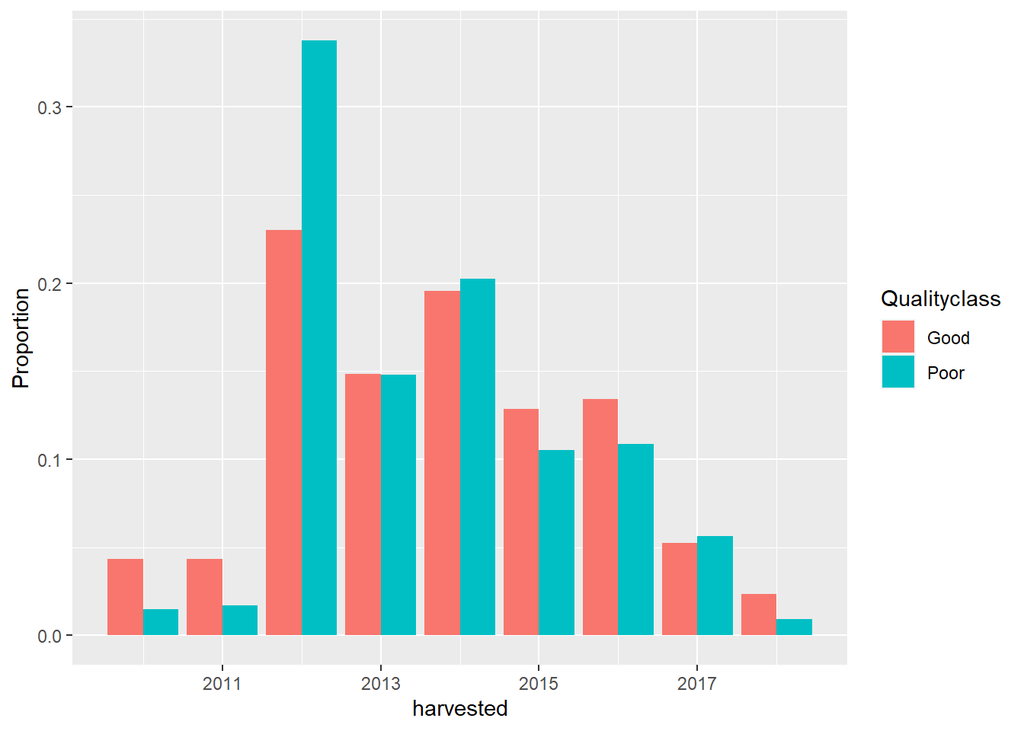

```r
ggplot(coffee, aes(x= harvested,  y = ..prop.., group=Qualityclass, fill=Qualityclass)) +
    geom_bar(position="dodge", stat="count") +
    labs(y = "Proportion")
```

I think we need to transform the num:year to chr:year

```r
co_Na$harvested <- as.character(co_Na$harvested)
```

#——————————-build model

```r
model_glm <- glm(class ~ aroma + flavor + acidity, data = co_Na,family = binomial(link = "logit"))
summary(model_glm)
```

```
##
## Call:
## glm(formula = class ~ aroma + flavor + acidity, family = binomial(link = "logit"),
##     data = co_Na)
##
## Deviance Residuals:
##     Min       1Q   Median       3Q      Max
## -4.1471  -0.3598   0.0012   0.4361   3.3188
##
## Coefficients:
##              Estimate Std. Error z value Pr(>|z|)
## (Intercept) -120.3387     8.4934 -14.169  < 2e-16 ***
## aroma          4.5044     0.6660   6.763 1.35e-11 ***
## flavor         7.0157     0.8325   8.428  < 2e-16 ***
## acidity        4.4230     0.6654   6.647 3.00e-11 ***
## ---
## Signif. codes:  0 '***' 0.001 '**' 0.01 '*' 0.05 '.' 0.1 ' ' 1
##
## (Dispersion parameter for binomial family taken to be 1)
##
##     Null deviance: 1296.13  on 934  degrees of freedom
## Residual deviance:  560.61  on 931  degrees of freedom
## AIC: 568.61
##
## Number of Fisher Scoring iterations: 7
```

```r
model_test <- glm(class ~ aroma + flavor + acidity + country_of_origin + category_two_defects + altitude_mean_meters + harvested, data = co_Na,family = binomial(link = "logit"))
summary(model_test)
```

```
##
## Call:
## glm(formula = class ~ aroma + flavor + acidity + country_of_origin +
##     category_two_defects + altitude_mean_meters + harvested,
##     family = binomial(link = "logit"), data = co_Na)
##
## Deviance Residuals:
##     Min       1Q   Median       3Q      Max
## -4.4725  -0.2531   0.0000   0.2883   3.4781
##
## Coefficients:
##                                                 Estimate Std. Error z value
## (Intercept)                                   -1.425e+02  1.139e+01 -12.507
## aroma                                          4.974e+00  8.274e-01   6.012
## flavor                                         8.356e+00  1.043e+00   8.008
## acidity                                        5.466e+00  8.172e-01   6.688
## country_of_originBurundi                       2.370e+00  4.766e+00   0.497
## country_of_originChina                         5.952e-01  1.073e+00   0.555
## country_of_originColombia                      2.132e+00  5.266e-01   4.048
## country_of_originCosta Rica                    4.251e-01  7.520e-01   0.565
## country_of_originCote d?Ivoire                -1.246e+01  6.523e+03  -0.002
## country_of_originEcuador                      -1.772e+00  1.484e+00  -1.194
## country_of_originEl Salvador                   6.952e-01  9.477e-01   0.734
## country_of_originEthiopia                      1.382e+01  9.392e+02   0.015
## country_of_originGuatemala                    -3.962e-01  5.082e-01  -0.780
## country_of_originHaiti                         2.090e+00  1.716e+00   1.218
## country_of_originHonduras                     -2.577e-01  6.556e-01  -0.393
## country_of_originIndia                        -2.836e+00  1.017e+00  -2.788
## country_of_originIndonesia                    -4.875e-02  9.704e-01  -0.050
## country_of_originKenya                         8.280e-01  1.578e+00   0.525
## country_of_originLaos                         -1.506e+01  4.474e+03  -0.003
## country_of_originMalawi                       -5.459e-01  1.263e+00  -0.432
## country_of_originMauritius                    -1.241e+01  6.523e+03  -0.002
## country_of_originMexico                       -6.235e-01  4.864e-01  -1.282
## country_of_originMyanmar                      -1.556e+01  2.375e+03  -0.007
## country_of_originNicaragua                     4.353e-01  1.949e+00   0.223
## country_of_originPanama                        3.442e+00  1.889e+00   1.822
## country_of_originPeru                         -1.396e+01  6.523e+03  -0.002
## country_of_originPhilippines                   2.959e+00  2.746e+00   1.078
## country_of_originTaiwan                        6.392e-01  6.552e-01   0.976
```

[output cut: 60 more lines]

```
## harvested2014                                  0.94800
## harvested2015                                  0.94270
## harvested2016                                  0.62598
## harvested2017                                  0.65754
## harvested2018                                  0.16472
## ---
## Signif. codes:  0 '***' 0.001 '**' 0.01 '*' 0.05 '.' 0.1 ' ' 1
##
## (Dispersion parameter for binomial family taken to be 1)
##
##     Null deviance: 1296.13  on 934  degrees of freedom
## Residual deviance:  458.01  on 889  degrees of freedom
## AIC: 550.01
##
## Number of Fisher Scoring iterations: 17
```

```r
model_test <- glm(class ~ aroma + flavor + acidity + country_of_origin + category_two_defects + altitude_mean_meters, data = co_Na,family = binomial(link = "logit"))
summary(model_test)
```

```
##
## Call:
## glm(formula = class ~ aroma + flavor + acidity + country_of_origin +
##     category_two_defects + altitude_mean_meters, family = binomial(link = "logit"),
##     data = co_Na)
##
## Deviance Residuals:
##     Min       1Q   Median       3Q      Max
## -4.4126  -0.2513   0.0000   0.2910   3.5418
##
## Coefficients:
##                                                 Estimate Std. Error z value
## (Intercept)                                   -1.383e+02  1.082e+01 -12.785
## aroma                                          4.745e+00  7.946e-01   5.971
## flavor                                         7.965e+00  1.000e+00   7.964
## acidity                                        5.585e+00  7.994e-01   6.987
## country_of_originBurundi                       2.142e+00  5.038e+00   0.425
## country_of_originChina                         1.581e-01  1.001e+00   0.158
## country_of_originColombia                      1.897e+00  4.806e-01   3.948
## country_of_originCosta Rica                    2.362e-01  7.035e-01   0.336
## country_of_originCote d?Ivoire                -1.244e+01  6.523e+03  -0.002
## country_of_originEcuador                      -1.670e+00  1.463e+00  -1.141
## country_of_originEl Salvador                   6.218e-01  9.312e-01   0.668
## country_of_originEthiopia                      1.390e+01  9.353e+02   0.015
## country_of_originGuatemala                    -5.621e-01  4.537e-01  -1.239
## country_of_originHaiti                         1.849e+00  1.792e+00   1.032
## country_of_originHonduras                     -3.361e-01  6.050e-01  -0.555
## country_of_originIndia                        -3.035e+00  9.807e-01  -3.095
## country_of_originIndonesia                    -3.344e-01  8.843e-01  -0.378
## country_of_originKenya                         1.121e+00  1.446e+00   0.775
## country_of_originLaos                         -1.546e+01  4.400e+03  -0.004
## country_of_originMalawi                       -1.021e+00  1.198e+00  -0.852
## country_of_originMauritius                    -1.247e+01  6.523e+03  -0.002
## country_of_originMexico                       -9.513e-01  4.232e-01  -2.248
## country_of_originMyanmar                      -1.606e+01  2.386e+03  -0.007
## country_of_originNicaragua                     2.559e-01  1.934e+00   0.132
## country_of_originPanama                        2.887e+00  1.852e+00   1.559
## country_of_originPeru                         -1.449e+01  6.523e+03  -0.002
## country_of_originPhilippines                   2.443e+00  2.614e+00   0.935
## country_of_originTaiwan                        3.318e-01  6.029e-01   0.550
```

[output cut: 44 more lines]

```
## country_of_originUnited States (Puerto Rico)   0.05560 .
## country_of_originVietnam                       0.07750 .
## country_of_originZambia                        0.99827
## category_two_defects                           0.07413 .
## altitude_mean_meters                           0.73992
## ---
## Signif. codes:  0 '***' 0.001 '**' 0.01 '*' 0.05 '.' 0.1 ' ' 1
##
## (Dispersion parameter for binomial family taken to be 1)
##
##     Null deviance: 1296.13  on 934  degrees of freedom
## Residual deviance:  466.14  on 897  degrees of freedom
## AIC: 542.14
##
## Number of Fisher Scoring iterations: 17
```

```r
model_year <- glm(class ~ harvested, data = co_Na,family = binomial(link = "logit"))
summary(model_year)
```

```
##
## Call:
## glm(formula = class ~ harvested, family = binomial(link = "logit"),
##     data = co_Na)
##
## Deviance Residuals:
##     Min       1Q   Median       3Q      Max
## -1.7125  -1.1774   0.7244   1.1146   1.3683
##
## Coefficients:
##               Estimate Std. Error z value Pr(>|z|)
## (Intercept)     1.2040     0.4655   2.587 0.009694 **
## harvested2011  -0.1924     0.6222  -0.309 0.757181
## harvested2012  -1.6422     0.4828  -3.401 0.000671 ***
## harvested2013  -1.0544     0.4967  -2.123 0.033753 *
## harvested2014  -1.2040     0.4871  -2.472 0.013450 *
## harvested2015  -1.0369     0.5002  -2.073 0.038184 *
## harvested2016  -1.0111     0.5055  -2.000 0.045467 *
## harvested2017  -1.3524     0.5396  -2.506 0.012198 *
## harvested2018  -0.2485     0.7026  -0.354 0.723600
## ---
## Signif. codes:  0 '***' 0.001 '**' 0.01 '*' 0.05 '.' 0.1 ' ' 1
##
## (Dispersion parameter for binomial family taken to be 1)
##
##     Null deviance: 1296.1  on 934  degrees of freedom
## Residual deviance: 1263.0  on 926  degrees of freedom
## AIC: 1281
##
## Number of Fisher Scoring iterations: 4
```

```r
model_country <- glm(class ~ country_of_origin, data = co_Na,family = binomial(link = "logit"))
summary(model_country)
```

```
##
## Call:
## glm(formula = class ~ country_of_origin, family = binomial(link = "logit"),
##     data = co_Na)
##
## Deviance Residuals:
##      Min        1Q    Median        3Q       Max
## -2.14597  -1.01655   0.00036   1.08424   2.18993
##
## Coefficients:
##                                                 Estimate Std. Error z value
## (Intercept)                                      0.08701    0.20871   0.417
## country_of_originBurundi                        -0.08701    1.42953  -0.061
## country_of_originChina                           0.50078    0.59554   0.841
## country_of_originColombia                        1.47591    0.31391   4.702
## country_of_originCosta Rica                      0.13613    0.39505   0.345
## country_of_originCote d?Ivoire                 -16.65308 2399.54473  -0.007
## country_of_originEcuador                        -0.08701    1.42953  -0.061
## country_of_originEl Salvador                     0.86850    0.56611   1.534
## country_of_originEthiopia                       16.47906  500.33970   0.033
## country_of_originGuatemala                      -0.04049    0.27310  -0.148
## country_of_originHaiti                          -1.47331    1.13735  -1.295
## country_of_originHonduras                       -1.15745    0.39429  -2.936
## country_of_originIndia                          -0.08701    0.66600  -0.131
## country_of_originIndonesia                       0.20067    0.57899   0.347
## country_of_originKenya                           2.11021    0.77403   2.726
## country_of_originLaos                          -16.65308 1696.73436  -0.010
## country_of_originMalawi                         -2.38960    1.06937  -2.235
## country_of_originMauritius                     -16.65308 2399.54473  -0.007
## country_of_originMexico                         -1.13298    0.26372  -4.296
## country_of_originMyanmar                       -16.65308  979.61005  -0.017
## country_of_originNicaragua                      -1.38629    0.68396  -2.027
## country_of_originPanama                          1.01160    1.17341   0.862
## country_of_originPeru                          -16.65308 2399.54473  -0.007
## country_of_originPhilippines                    -0.49248    0.93643  -0.526
## country_of_originTaiwan                         -0.47788    0.34125  -1.400
## country_of_originTanzania, United Republic Of   -0.15600    0.42621  -0.366
## country_of_originThailand                        0.20067    0.57899   0.347
## country_of_originUganda                          1.10257    0.47947   2.300
## country_of_originUnited States                   0.60614    0.73727   0.822
```

[output cut: 33 more lines]

```
## country_of_originUnited States                 0.41100
## country_of_originUnited States (Hawaii)        0.99452
## country_of_originUnited States (Puerto Rico)   0.53004
## country_of_originVietnam                       0.79992
## country_of_originZambia                        0.99446
## ---
## Signif. codes:  0 '***' 0.001 '**' 0.01 '*' 0.05 '.' 0.1 ' ' 1
##
## (Dispersion parameter for binomial family taken to be 1)
##
##     Null deviance: 1296.1  on 934  degrees of freedom
## Residual deviance: 1077.4  on 902  degrees of freedom
## AIC: 1143.4
##
## Number of Fisher Scoring iterations: 15
```

```r
model_cn_ye <- glm(class ~ country_of_origin + harvested, data = co_Na,family = binomial(link = "logit"))
summary(model_cn_ye)
```

```
##
## Call:
## glm(formula = class ~ country_of_origin + harvested, family = binomial(link = "logit"),
##     data = co_Na)
##
## Deviance Residuals:
##      Min        1Q    Median        3Q       Max
## -2.16586  -0.97714   0.00032   1.00332   2.18993
##
## Coefficients:
##                                                 Estimate Std. Error z value
## (Intercept)                                    3.047e-03  5.948e-01   0.005
## country_of_originBurundi                       1.376e-01  1.439e+00   0.096
## country_of_originChina                         7.241e-01  6.292e-01   1.151
## country_of_originColombia                      1.807e+00  3.395e-01   5.322
## country_of_originCosta Rica                    4.547e-01  4.201e-01   1.082
## country_of_originCote d?Ivoire                -1.658e+01  2.400e+03  -0.007
## country_of_originEcuador                       3.015e-01  1.456e+00   0.207
## country_of_originEl Salvador                   1.136e+00  5.840e-01   1.945
## country_of_originEthiopia                      1.679e+01  4.978e+02   0.034
## country_of_originGuatemala                     3.536e-01  3.041e-01   1.163
## country_of_originHaiti                        -9.782e-01  1.153e+00  -0.848
## country_of_originHonduras                     -9.299e-01  4.172e-01  -2.229
## country_of_originIndia                         2.446e-01  6.894e-01   0.355
## country_of_originIndonesia                     3.986e-01  5.999e-01   0.664
## country_of_originKenya                         2.550e+00  7.908e-01   3.225
## country_of_originLaos                         -1.661e+01  1.697e+03  -0.010
## country_of_originMalawi                       -1.951e+00  1.092e+00  -1.786
## country_of_originMauritius                    -1.658e+01  2.400e+03  -0.007
## country_of_originMexico                       -7.528e-01  3.130e-01  -2.405
## country_of_originMyanmar                      -1.657e+01  9.761e+02  -0.017
## country_of_originNicaragua                    -1.251e+00  7.005e-01  -1.785
## country_of_originPanama                        1.455e+00  1.187e+00   1.226
## country_of_originPeru                         -1.628e+01  2.400e+03  -0.007
## country_of_originPhilippines                  -1.539e-01  9.529e-01  -0.161
## country_of_originTaiwan                       -1.395e-01  3.716e-01  -0.375
## country_of_originTanzania, United Republic Of  1.832e-01  4.571e-01   0.401
## country_of_originThailand                      5.764e-01  6.008e-01   0.959
## country_of_originUganda                        1.641e+00  5.168e-01   3.175
## country_of_originUnited States                 1.037e+00  7.651e-01   1.356
```

[output cut: 49 more lines]

```
## harvested2014                                  0.54710
## harvested2015                                  0.90959
## harvested2016                                  0.99139
## harvested2017                                  0.49290
## harvested2018                                  0.32506
## ---
## Signif. codes:  0 '***' 0.001 '**' 0.01 '*' 0.05 '.' 0.1 ' ' 1
##
## (Dispersion parameter for binomial family taken to be 1)
##
##     Null deviance: 1296.1  on 934  degrees of freedom
## Residual deviance: 1065.9  on 894  degrees of freedom
## AIC: 1147.9
##
## Number of Fisher Scoring iterations: 15
```

```r
stepAIC(model_test, direction = 'both')
```

```
## Start:  AIC=542.14
## class ~ aroma + flavor + acidity + country_of_origin + category_two_defects +
##     altitude_mean_meters
```

```
##                        Df Deviance    AIC
## - altitude_mean_meters  1   466.31 540.31
## <none>                      466.14 542.14
## - category_two_defects  1   469.17 543.17
## - country_of_origin    32   559.98 571.98
## - aroma                 1   517.27 591.27
## - acidity               1   528.01 602.01
## - flavor                1   555.95 629.95
```

```
##
## Step:  AIC=540.31
## class ~ aroma + flavor + acidity + country_of_origin + category_two_defects
```

```
##                        Df Deviance    AIC
## <none>                      466.31 540.31
## - category_two_defects  1   469.37 541.37
## + altitude_mean_meters  1   466.14 542.14
## - country_of_origin    32   560.42 570.42
## - aroma                 1   517.72 589.72
## - acidity               1   528.15 600.15
## - flavor                1   556.58 628.58
```

```
##
## Call:  glm(formula = class ~ aroma + flavor + acidity + country_of_origin +
##     category_two_defects, family = binomial(link = "logit"),
##     data = co_Na)
##
## Coefficients:
##                                   (Intercept)
##                                     -138.5901
##                                         aroma
##                                        4.7601
##                                        flavor
##                                        7.9877
##                                       acidity
##                                        5.5857
##                      country_of_originBurundi
##                                        2.1421
##                        country_of_originChina
##                                        0.1546
##                     country_of_originColombia
##                                        1.8942
##                   country_of_originCosta Rica
##                                        0.2345
##                country_of_originCote d?Ivoire
##                                      -12.4232
##                      country_of_originEcuador
##                                       -1.6654
##                  country_of_originEl Salvador
##                                        0.6202
##                     country_of_originEthiopia
##                                       13.8876
##                    country_of_originGuatemala
##                                       -0.5802
##                        country_of_originHaiti
##                                        1.8537
##                     country_of_originHonduras
##                                       -0.3375
##                        country_of_originIndia
##                                       -3.0428
##                    country_of_originIndonesia
##                                       -0.3381
```

[output cut: 29 more lines]

```
##                                       -0.1566
##       country_of_originUnited States (Hawaii)
##                                        4.0495
##  country_of_originUnited States (Puerto Rico)
##                                       -3.1452
##                      country_of_originVietnam
##                                        1.9889
##                       country_of_originZambia
##                                      -14.1569
##                          category_two_defects
##                                        0.0583
##
## Degrees of Freedom: 934 Total (i.e. Null);  898 Residual
## Null Deviance:       1296
## Residual Deviance: 466.3     AIC: 540.3
```

#——————————–test model

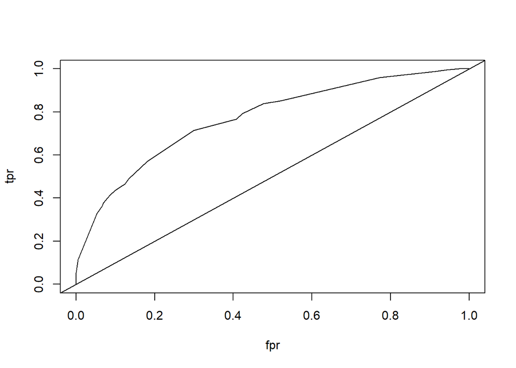

```r
pre <- predict(model_country,type='response')

data <- data.frame(prob=pre,obs=co_Na$class)

data <- data[order(data$prob),]
n <- nrow(data)
tpr <- fpr <- rep(0,n)

for (i in 1:n) {
    threshold <- data$prob[i]
    tp <- sum(data$prob > threshold & data$obs == "Good")
    fp <- sum(data$prob > threshold & data$obs == "Poor")
    tn <- sum(data$prob < threshold & data$obs == "Poor")
    fn <- sum(data$prob < threshold & data$obs == "Good")
    tpr[i] <- tp/(tp+fn) # 真正率
    fpr[i] <- fp/(tn+fp) # 假正率
}
plot(fpr,tpr,type='l')
abline(a=0,b=1)
```

```r
pred <- prediction(pre,co_Na$class)
performance(pred,'auc')@y.values #AUC值
```

```
## [[1]]
## [1] 0.2462662
```

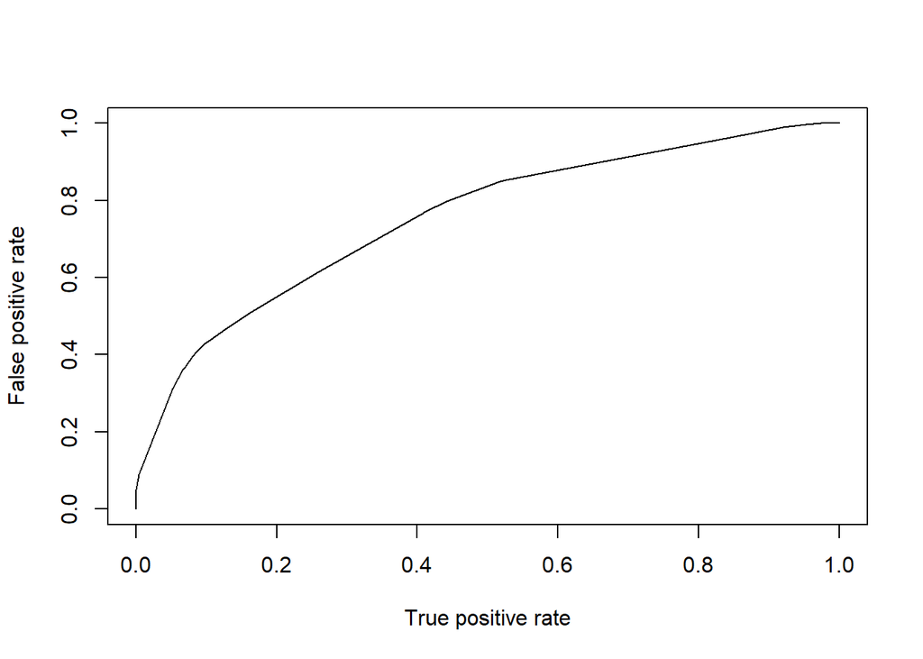

```r
perf <- performance(pred,'fpr','tpr')
plot(perf)
```

#——————